# Titanic - Survivor Predictor

Mekala

2 December 2018

## Use Case:

### Let us take the Titanic Data set and build a model which will predict the survival probability - whether or not a passenger would have survived if travelled on Titanic. This can be a prototype to predict accident probability / Air crash Probability predictor and many other such use cases.

## Data Set:

### Titanic data set contains various data points about each passenger who was onboard in the Titanic Ship. The data set aslo contains whether the passenger survived the crash or not.

### Step 1 Import data

```r
df.train<-read.csv('C:\\Users\\Arun61\\Desktop\\DATA SCIENCE\\Megha Files\\01.12.18\\Classification\\Titanic\\titanic_train.csv')
head(df.train)
```

```
##   PassengerId Survived Pclass
## 1           1        0      3
## 2           2        1      1
## 3           3        1      3
## 4           4        1      1
## 5           5        0      3
## 6           6        0      3
##                                                  Name    Sex Age SibSp
## 1                             Braund, Mr. Owen Harris   male  22     1
## 2 Cumings, Mrs. John Bradley (Florence Briggs Thayer) female  38     1
## 3                              Heikkinen, Miss. Laina female  26     0
## 4        Futrelle, Mrs. Jacques Heath (Lily May Peel) female  35     1
## 5                            Allen, Mr. William Henry   male  35     0
## 6                                    Moran, Mr. James   male  NA     0
##   Parch           Ticket    Fare Cabin Embarked
## 1     0        A/5 21171  7.2500              S
## 2     0         PC 17599 71.2833   C85        C
## 3     0 STON/O2. 3101282  7.9250              S
## 4     0           113803 53.1000  C123        S
## 5     0           373450  8.0500              S
## 6     0           330877  8.4583              Q
```

```r
df.train[]
```

[output not shown]

[output cut: 3553 more lines]

```r
df.train[,6:8]
```

[output not shown]

[output cut: 877 more lines]

## Exploratory Data Analysis (EDA)

### Let us explore how much missing data we have, we can use the Amelia pacakge for this

```r
library(Amelia)
```

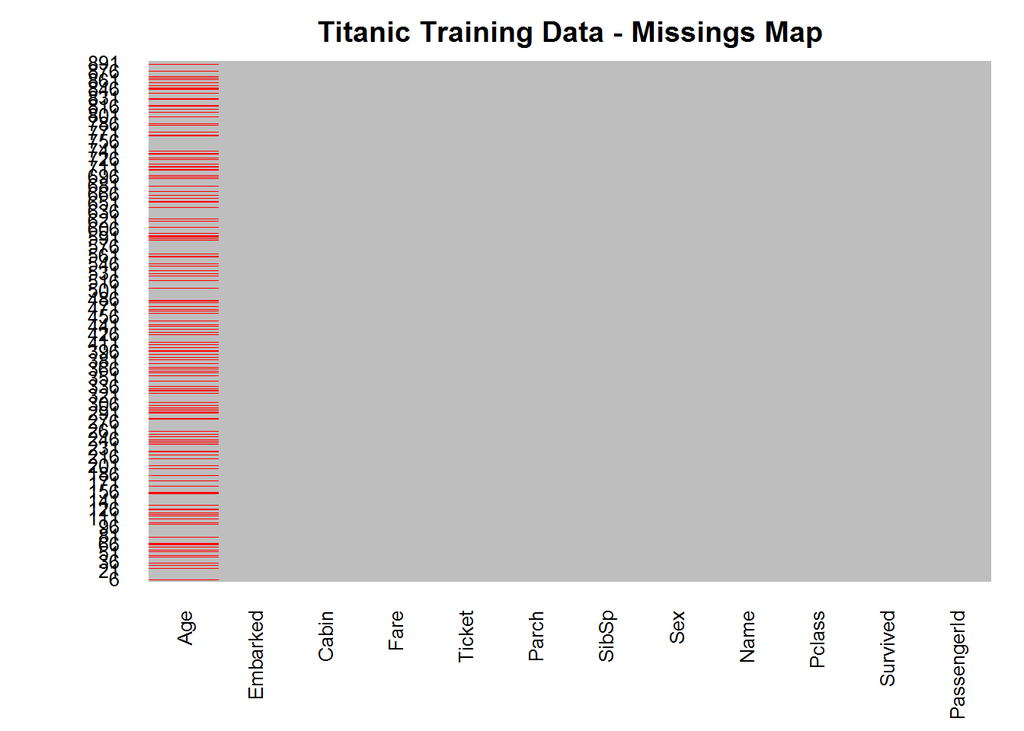

```r
missmap(df.train,main = "Titanic Training Data - Missings Map",col = c("RED","GRAY"),legend =FALSE)
```

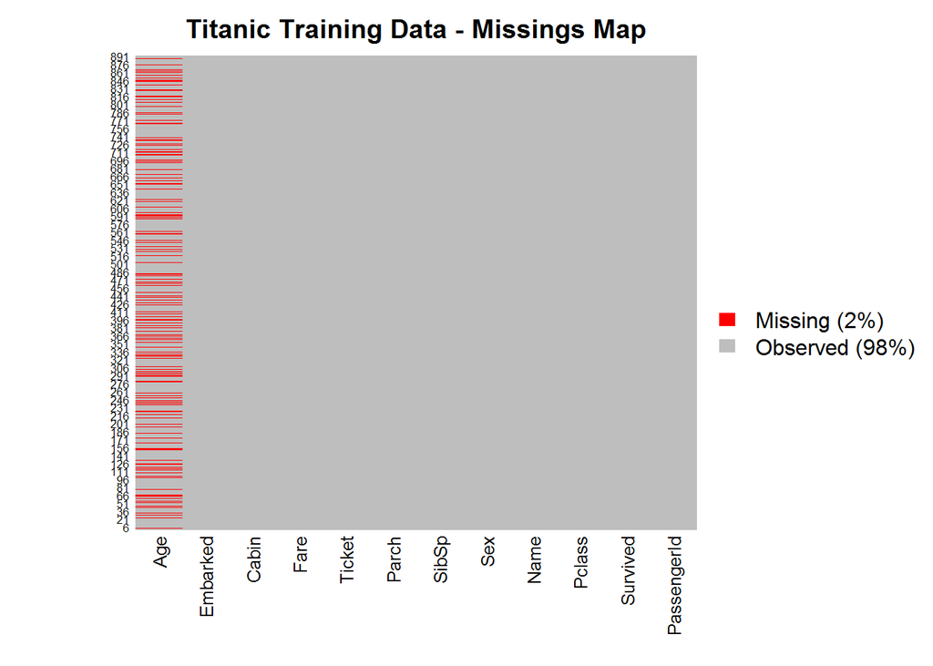

```r
missmap(df.train,main = "Titanic Training Data - Missings Map",col = c("RED","GRAY"),legend =TRUE,y.cex=0.5)
```

### 2 percent of the data is missing. We shall come up with a way to fil this missing data.

## Data Vizulization

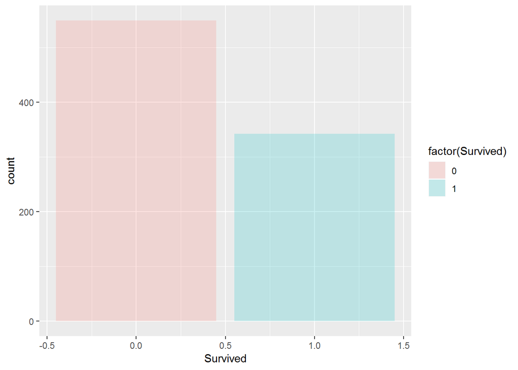

```r
library(ggplot2)
ggplot(df.train,aes(Survived))+geom_bar(aes(fill=factor(Survived)),alpha=0.2)
```

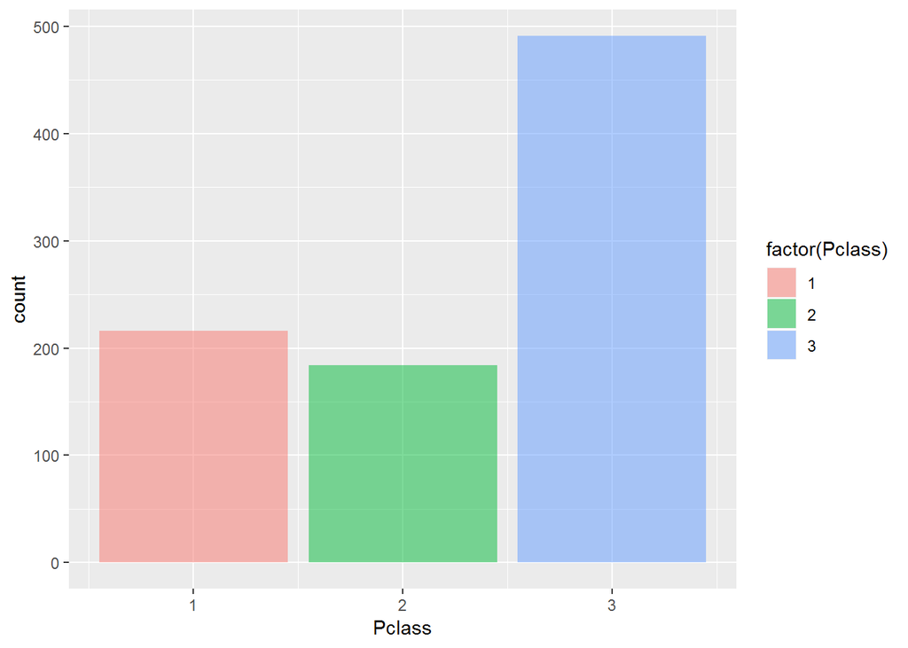

```r
library(ggplot2)
ggplot(df.train,aes(Pclass))+geom_bar(aes(fill=factor(Pclass)),alpha=0.5)
```

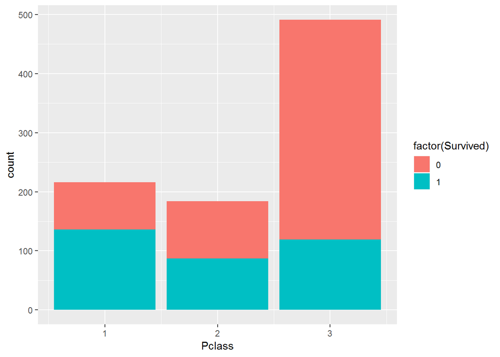

```r
g<-ggplot(df.train,aes(Pclass))+geom_bar()
g+geom_bar(aes(fill=factor(Survived)))
```

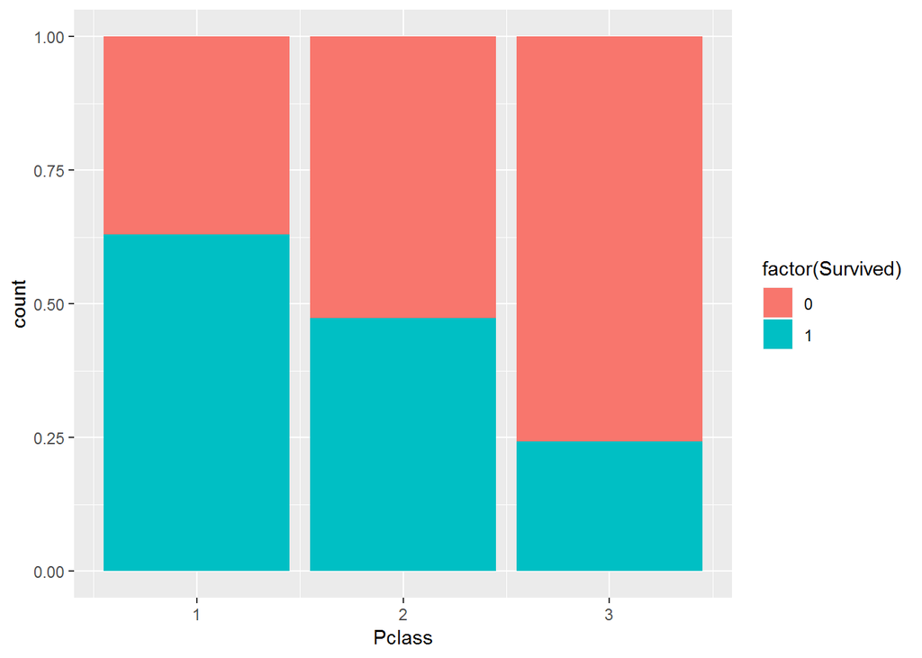

```r
g1<-ggplot(df.train,aes(Pclass))
g1 + geom_bar(aes(fill = factor(Survived)), position = "fill")
```

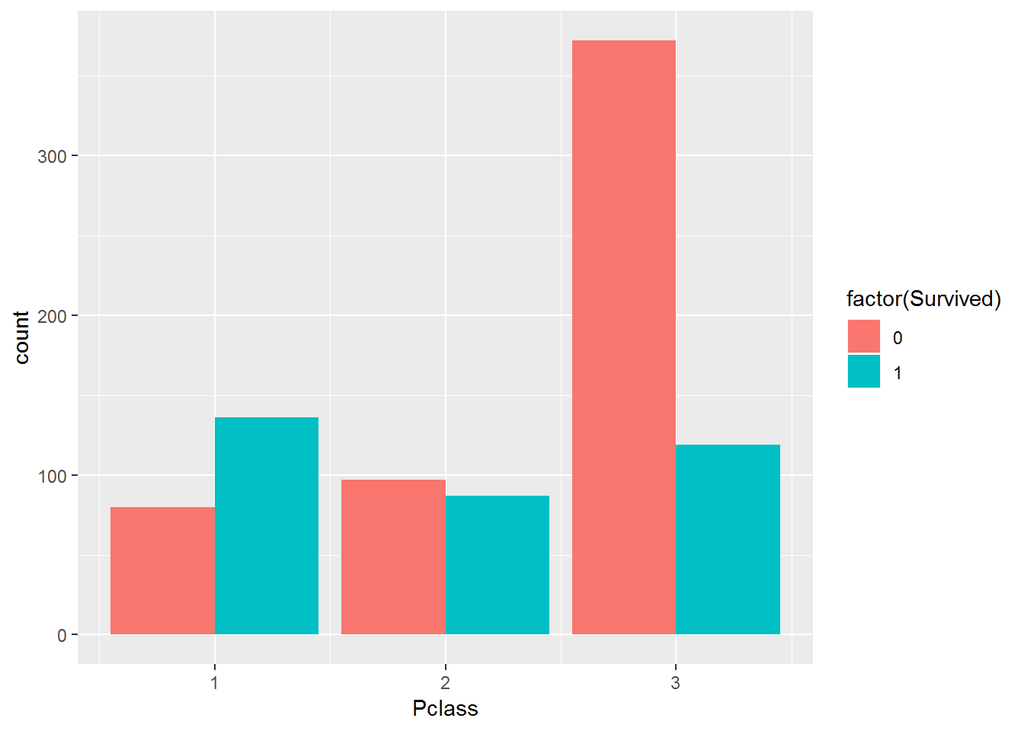

```r
g1<-ggplot(df.train,aes(Pclass))
g1 + geom_bar(aes(fill = factor(Survived)), position = "dodge")
```

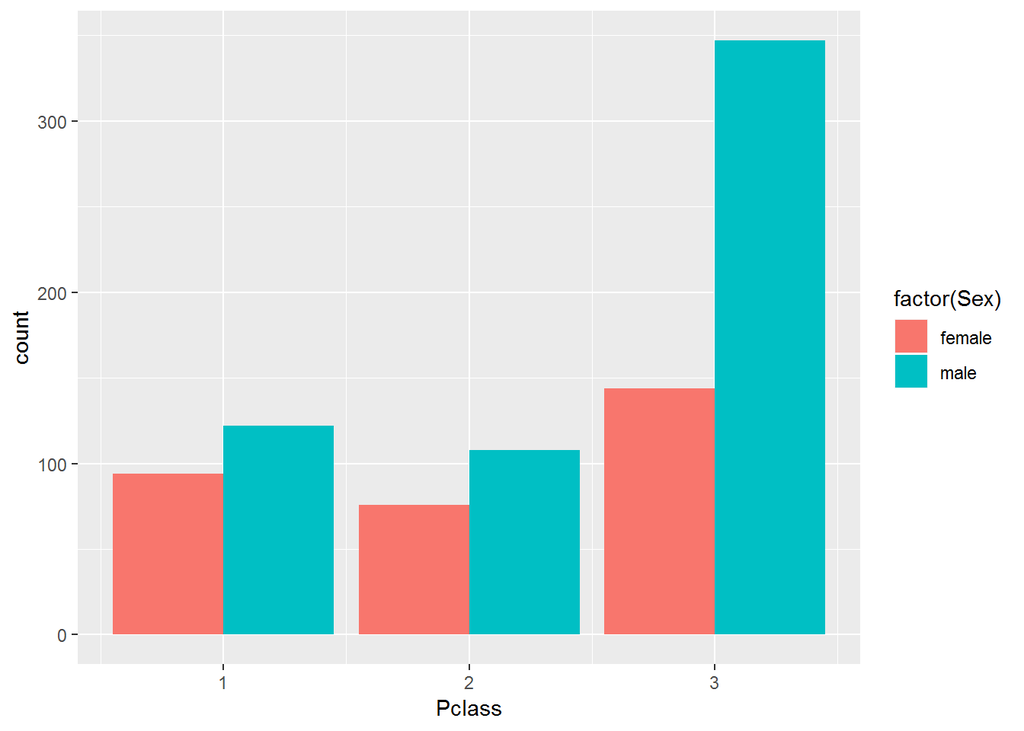

```r
ggplot(df.train,aes(Pclass))+geom_bar(aes(fill=factor(Sex)),position="dodge")
```

###We want to fill in missing age data instead of just dropping the missing age data rows.

### One way to do this is by filling in the mean age of all the passengers (imputation).

### The other way is to see if there is a pattern relationship between any other column and age. Fill the age accordingly.

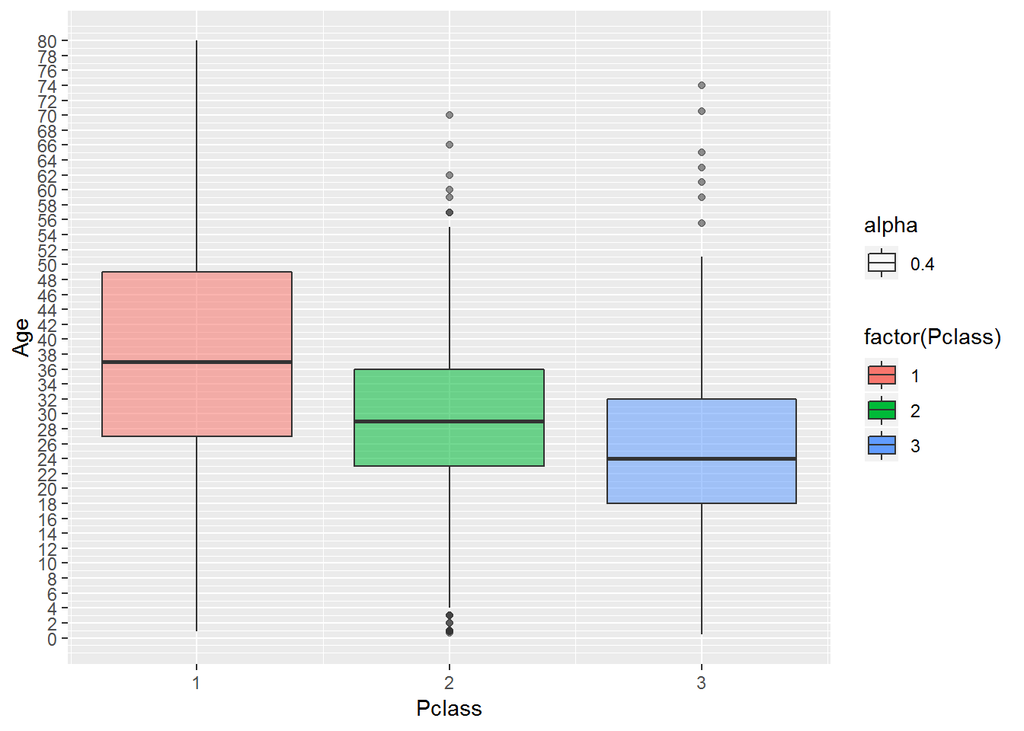

```r
g3<-ggplot(df.train,aes(Pclass,Age))+geom_boxplot(aes(group=Pclass,fill=factor(Pclass),alpha=0.4))
g3+scale_y_continuous(breaks=seq(min(0),max(80),by = 2))
```

###We shall use these average age values to impute based on Pclass for Age. Because we see that avg age is different for each class.

```r
impute_age<-function(age,class){
  out<-age
  for(i in 1:length(age)){
    if(is.na(age[i])){
      if(class[i]==1){
        out[i]<-37
        }else if(class[i]==2){
          out[i]<-29
          }else{
            out[i]<-24
        }
    }else{
      out[i]<-age[i]
    }
  }
  return(out)
}
```

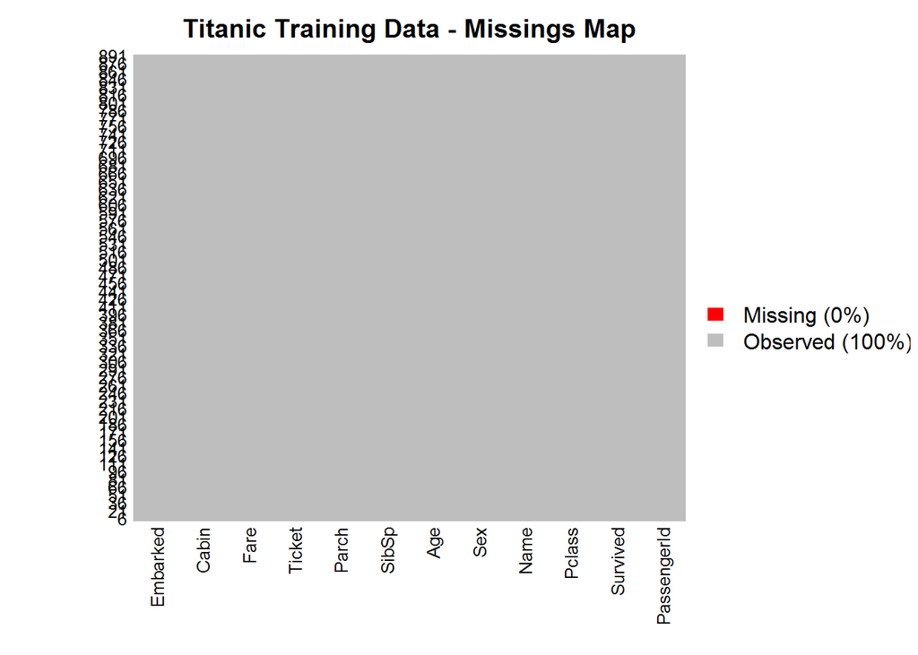

```r
fixed.ages<-impute_age(df.train$Age,df.train$Pclass)
df.train$Age<-fixed.ages
missmap(df.train,main = "Titanic Training Data - Missings Map",col = c("RED","GRAY"),legend =TRUE)
```

###Now there is no missing values in the data set.

### Rather than using all the columns to build the model, let us use specific columns as input signals for the model.

```r
df.train<-df.train[,!colnames(df.train) %in% c('PassengerId','Ticket','Cabin','Name')]
```

## Split the data

```r
library(caTools)
set.seed=101

split=sample.split(df.train$Survived,SplitRatio = 0.7)
final.train = subset(df.train,split==TRUE)
final.test = subset(df.train,split==FALSE)
```

## Decision Tree Model

```r
library(rpart)
tree<-rpart(Survived ~.,method='class',data=final.train)
```

### Prediction

```r
tree.preds<-predict(tree,final.test)
head(tree.preds)
```

```
##            0         1
## 3  0.6470588 0.3529412
## 5  0.8316327 0.1683673
## 7  0.8316327 0.1683673
## 8  0.2500000 0.7500000
## 12 0.0500000 0.9500000
## 18 0.8316327 0.1683673
```

```r
class(tree.preds)
```

```
## [1] "matrix"
```

```r
tree.preds<-as.data.frame(tree.preds)
joiner<-function(X){
  if(X>=0.5){
    return('1')
  }else{
    return('0')
    }
}
```

```r
tree.preds$Survival<-sapply(tree.preds$`1`,joiner)
head(tree.preds)
```

```
##            0         1 Survival
## 3  0.6470588 0.3529412        0
## 5  0.8316327 0.1683673        0
## 7  0.8316327 0.1683673        0
## 8  0.2500000 0.7500000        1
## 12 0.0500000 0.9500000        1
## 18 0.8316327 0.1683673        0
```

### Accuracy

```r
tree.error <- mean(tree.preds$Survival != final.test$Survived)
print(paste('Accuracy is',1-tree.error))
```

```
## [1] "Accuracy is 0.802238805970149"
```

### RandomForest

```r
library(randomForest)
rf.model <- randomForest(Survived ~ .,data = final.train)
p <- predict(rf.model,final.test)
joiner <- function(x){
  if (x>=0.5){
    return('1')
  }else{
    return('0')
  }
}
 p <- sapply(p,joiner)

 table(p,final.test$Survived)
```

```
##
## p     0   1
##   0 150  30
##   1  15  73
```

### Accuracy

```r
rf.error <- mean(p !=final.test$Survived)
print(paste('Accuarcy of Random Forest',1-rf.error))
```

```
## [1] "Accuarcy of Random Forest 0.832089552238806"
```

### KNN Classifier

```r
titanic.std <- scale(df.train[,!(colnames(df.train) %in% c('Sex','Embarked','survived'))])
std.titanic <- data.frame(titanic.std)
```

```r
std.titanic$Survived <- df.train$Survived
head(std.titanic)
```

```
##   Survived     Pclass        Age      SibSp      Parch       Fare
## 1        0  0.8269128 -0.5335340  0.4325504 -0.4734077 -0.5021631
## 2        1 -1.5652278  0.6745117  0.4325504 -0.4734077  0.7864036
## 3        1  0.8269128 -0.2315226 -0.4742788 -0.4734077 -0.4885799
## 4        1 -1.5652278  0.4480031  0.4325504 -0.4734077  0.4204941
## 5        0  0.8269128  0.4480031 -0.4742788 -0.4734077 -0.4860644
## 6        0  0.8269128 -0.3825283 -0.4742788 -0.4734077 -0.4778481
```

```r
library(caTools)
set.seed(101)

split <- sample.split(std.titanic$Survived,SplitRatio = 0.7)
split.train = subset(std.titanic,split==TRUE)
split.test = subset(std.titanic,split==FALSE)
head(split.train)
```

```
##   Survived     Pclass        Age      SibSp      Parch       Fare
## 1        0  0.8269128 -0.5335340  0.4325504 -0.4734077 -0.5021631
## 2        1 -1.5652278  0.6745117  0.4325504 -0.4734077  0.7864036
## 3        1  0.8269128 -0.2315226 -0.4742788 -0.4734077 -0.4885799
## 5        0  0.8269128  0.4480031 -0.4742788 -0.4734077 -0.4860644
## 7        0 -1.5652278  1.8825574 -0.4742788 -0.4734077  0.3955914
## 8        0  0.8269128 -2.0435912  2.2462089  0.7671990 -0.2239573
```

```r
head(split.test)
```

```
##    Survived     Pclass         Age      SibSp      Parch        Fare
## 4         1 -1.5652278  0.44800311  0.4325504 -0.4734077  0.42049407
## 6         0  0.8269128 -0.38252832 -0.4742788 -0.4734077 -0.47784805
## 12        1 -1.5652278  2.18456883 -0.4742788 -0.4734077 -0.11378180
## 21        0 -0.3691575  0.44800311 -0.4742788 -0.4734077 -0.12484967
## 22        1 -0.3691575  0.37250025 -0.4742788 -0.4734077 -0.38645367
## 24        1 -1.5652278 -0.08051689 -0.4742788 -0.4734077  0.06632249
```

```r
split.train[,2:6]
```

[output not shown]

[output cut: 609 more lines]

```r
head(split.train[,2:6])
```

```
##       Pclass        Age      SibSp      Parch       Fare
## 1  0.8269128 -0.5335340  0.4325504 -0.4734077 -0.5021631
## 2 -1.5652278  0.6745117  0.4325504 -0.4734077  0.7864036
## 3  0.8269128 -0.2315226 -0.4742788 -0.4734077 -0.4885799
## 5  0.8269128  0.4480031 -0.4742788 -0.4734077 -0.4860644
## 7 -1.5652278  1.8825574 -0.4742788 -0.4734077  0.3955914
## 8  0.8269128 -2.0435912  2.2462089  0.7671990 -0.2239573
```

```r
library(class)
knn.modelpredict <- knn(split.train,split.test,split.train$Survived,k=1)
head(knn.modelpredict)
```

```
## [1] 1 0 1 0 1 1
## Levels: 0 1
```

```r
knn.modelpreds <-knn(split.train[,2:6],split.test[,2:6],split.train$Survived,k=1)
head(knn.modelpreds)
```

```
## [1] 0 0 0 1 0 1
## Levels: 0 1
```

```r
knn.error <- mean(knn.modelpreds != split.test$Survived)
print(paste('Accuracy of Knn for k = 1 is', 1-knn.error))
```

```
## [1] "Accuracy of Knn for k = 1 is 0.652985074626866"
```

```r
knn.modelpreds <-knn(split.train[,2:6],split.test[,2:6],split.train$Survived,k=6)
head(knn.modelpreds)
```

```
## [1] 0 0 0 1 1 0
## Levels: 0 1
```

```r
knn.error <- mean(knn.modelpreds != split.test$Survived)
print(paste('Accuracy of Knn for k = 6 is', 1-knn.error))
```

```
## [1] "Accuracy of Knn for k = 6 is 0.697761194029851"
```

```r
knn.pred = NULL
knn.err = NULL

for (i in 1:20) {
  set.seed(101)
  knn.pred <- knn(split.train[,2:6],split.test[,2:6],split.train$Survived,k=i)
  knn.err[i] <- mean(knn.pred != split.test$Survived)

}

print(knn.err)
```

```
##  [1] 0.3432836 0.3470149 0.3320896 0.3320896 0.2947761 0.3059701 0.2947761
##  [8] 0.3059701 0.3022388 0.2985075 0.2723881 0.2798507 0.2910448 0.2798507
## [15] 0.2835821 0.2723881 0.2761194 0.2835821 0.2835821 0.2761194
```

```r
library(ggplot2)
k.values <- 1:20
error.df <- data.frame(knn.err,k.values)
error.df
```

```
##      knn.err k.values
## 1  0.3432836        1
## 2  0.3470149        2
## 3  0.3320896        3
## 4  0.3320896        4
## 5  0.2947761        5
## 6  0.3059701        6
## 7  0.2947761        7
## 8  0.3059701        8
## 9  0.3022388        9
## 10 0.2985075       10
## 11 0.2723881       11
## 12 0.2798507       12
## 13 0.2910448       13
## 14 0.2798507       14
## 15 0.2835821       15
## 16 0.2723881       16
## 17 0.2761194       17
## 18 0.2835821       18
## 19 0.2835821       19
## 20 0.2761194       20
```

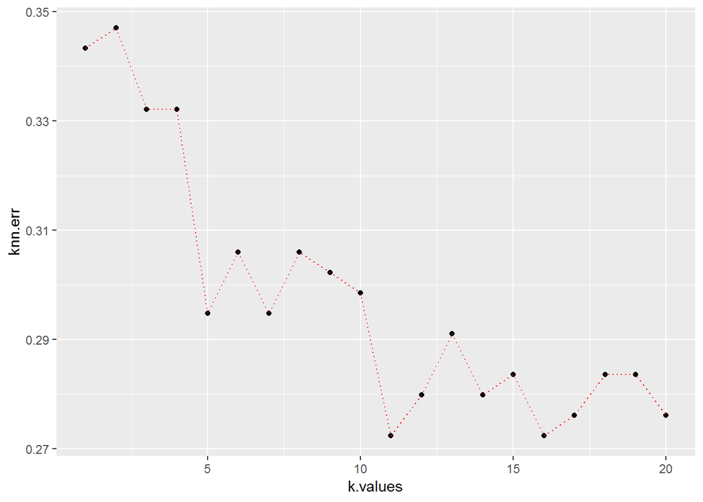

```r
ggplot(error.df,aes(x=k.values,y=knn.err))+geom_point()+geom_line(lty='dotted',color='red')
```

```r
knn.modelpreds <-knn(split.train[,2:6],split.test[,2:6],split.train$Survived,k=11)
head(knn.modelpreds)
```

```
## [1] 1 0 0 0 0 1
## Levels: 0 1
```

## Accuracy

```r
knn.error <- mean(knn.modelpreds != split.test$Survived)
print(paste('Accuracy of Knn for k = 11 is', 1-knn.error))
```

```
## [1] "Accuracy of Knn for k = 11 is 0.723880597014925"
```

```r
table(knn.modelpreds,split.test$Survived)
```

```
##
## knn.modelpreds   0   1
##              0 135  44
##              1  30  59
```

## Logistic Regression Classifier

### Building the Model:

```r
log.model <- glm(formula=Survived ~ . , family = binomial(link='logit'),data = final.train)
```

### Prediction for test data:

```r
fitted.probabilities <- predict(log.model,newdata=final.test,type='response')
```

### Accuracy Measurement:

```r
fitted.results <- ifelse(fitted.probabilities > 0.5,1,0)
misClasificError <- mean(fitted.results != final.test$Survived)
print(paste('Accuracy',1-misClasificError))
```

```
## [1] "Accuracy 0.794776119402985"
```